# Лабораторная работа №3

Дисциплина: Компьютерный практикум по статистическому анализу данных

Манаева Варвара Евгеньевна.

Российский университет дружбы народов, Москва, Россия

17 ноября 2023

# Цели и задачи работы

## Цель

Освоить применение циклов функций и сторонних для Julia пакетов для решения задач линейной алгебры и работы с матрицами.

## Задачи

1. Используя Jupyter Lab, повторите примеры из раздела 3.2.
2. Выполните задания для самостоятельной работы (раздел 3.4).

# Выполнение лабораторной работы

# Повторение примеров

## Повторение примеров (1)

1. Циклы `while` и `for`;
2. Условные выражения;
3. Функции;
4. Сторонние библиотеки (пакеты) в Julia.

## Повторение примеров (2)

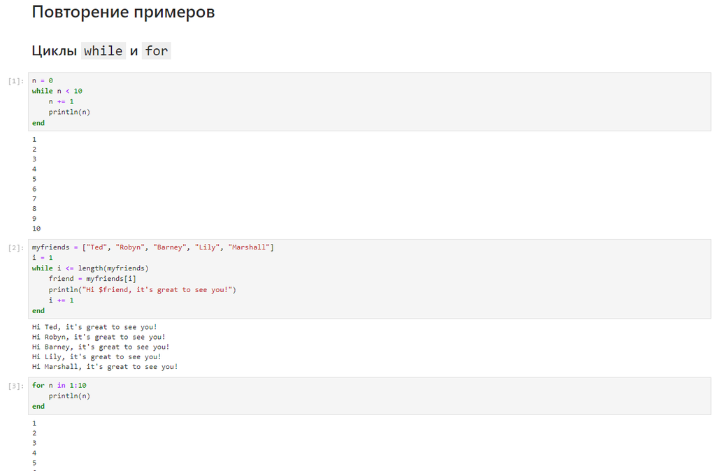

## Повторение примеров (3)

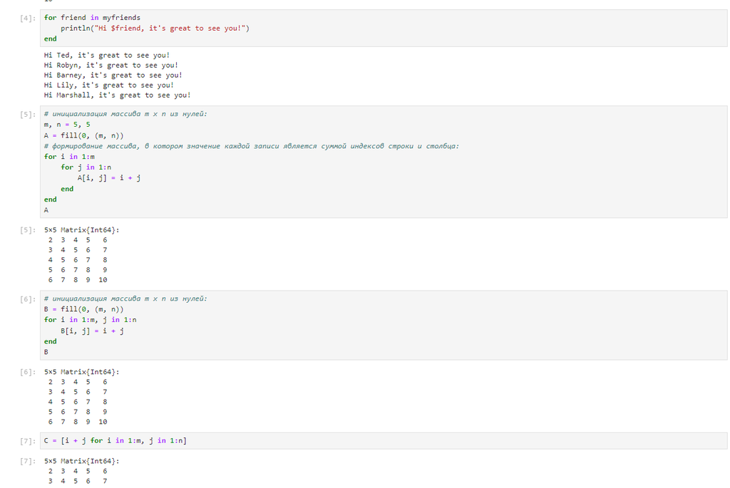

## Повторение примеров (4)

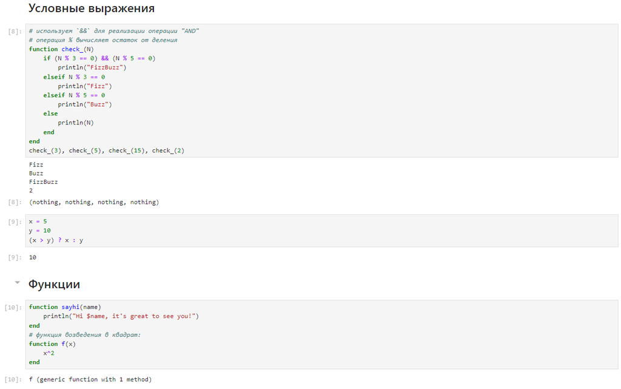

## Повторение примеров (5)

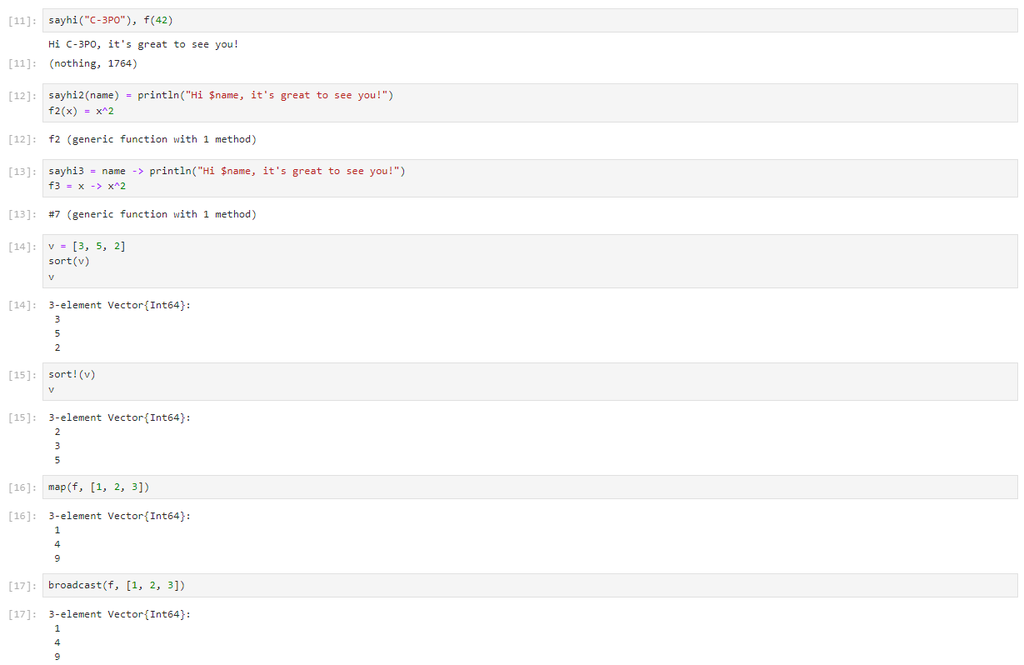

## Повторение примеров (6)

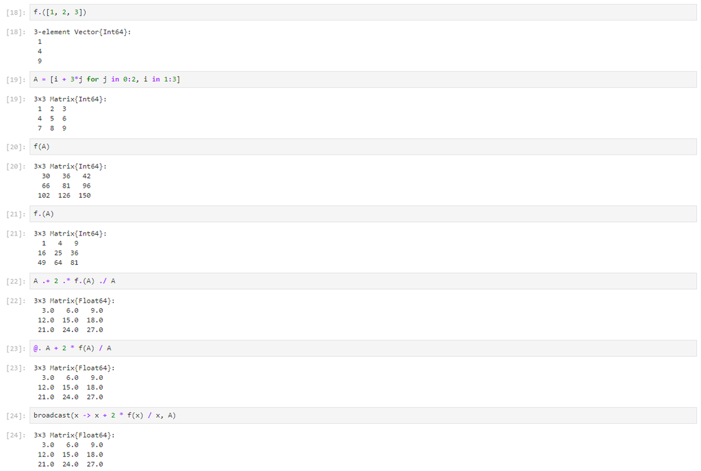

## Повторение примеров (7)

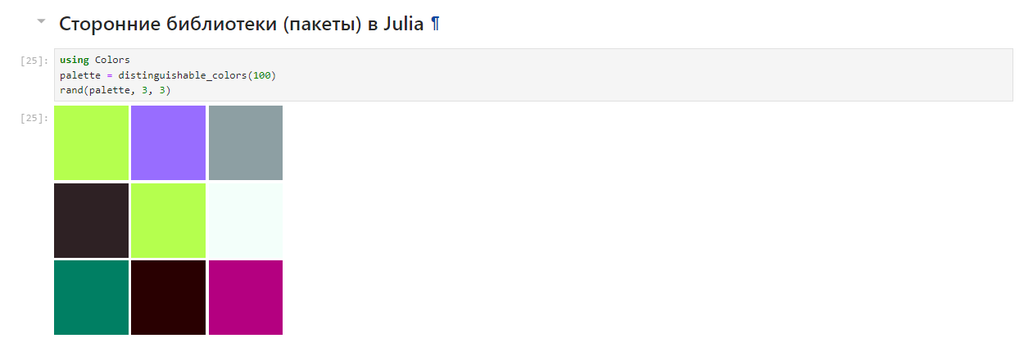

# Самостоятельная работа

## 1. Используя циклы while и for: (1)

- выведите на экран целые числа от 1 до 100 и напечатайте их квадраты;
- создайте словарь squares, который будет содержать целые числа в качестве ключей и квадраты в качестве их пар-значений;
- создайте массив squares_arr, содержащий квадраты всех чисел от 1 до 100.

## 1. Используя циклы while и for: (2)

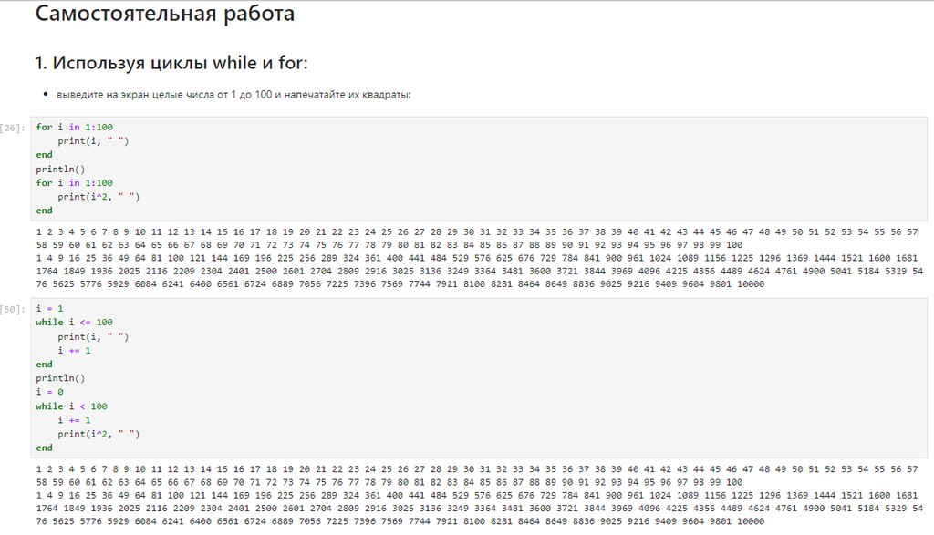

Циклы `while` и `for` (1)

## 1. Используя циклы while и for: (3)

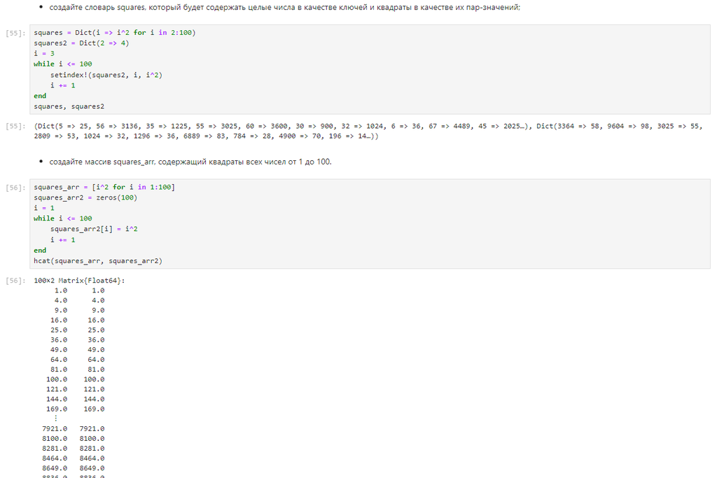

Циклы `while` и `for` (2)

## 2. Напишите условный оператор, который печатает число, если число чётное, и строку «нечётное», если число нечётное.

Перепишите код, используя тернарный оператор.

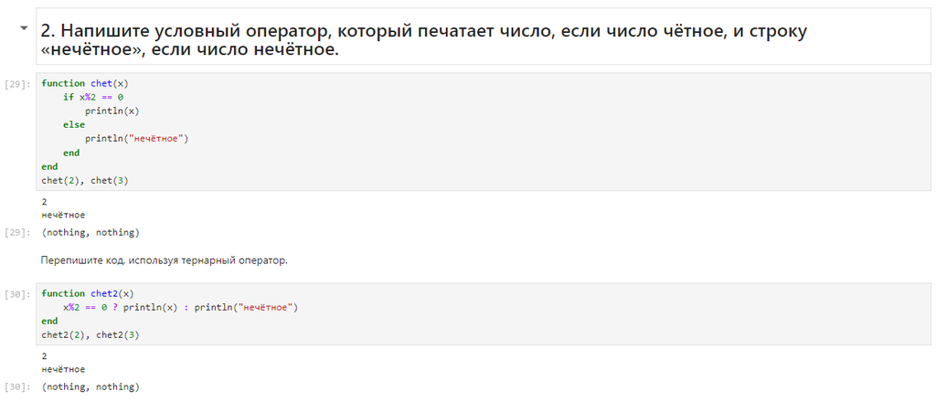

Условные операторы

## 3. Напишите функцию `add_one`, которая добавляет $1$ к своему входу.

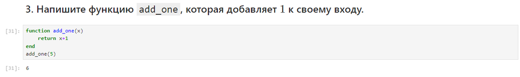

Функция `add_one`

## 4. Используйте `map()` или `broadcast()` для задания матрицы *A*, каждый элемент которой увеличивается на единицу по сравнению с предыдущим.

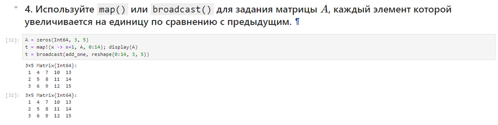

Использование `map()` и `broadcast()`

## 5. Задайте матрицу *A* определённого вида:

- Найдите *A*<sup>3</sup>
- Замените третий столбец матрицы *A* на сумму 2-го и 3-го столбцов

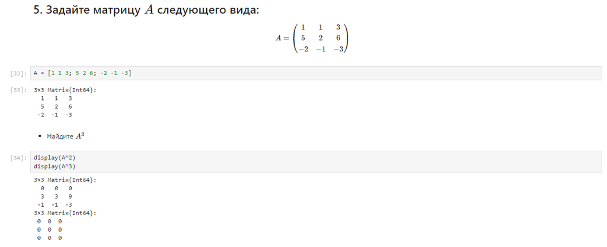

Матрица

## 6. Создайте матрицу *B* с элементами *B*<sub>*i*1</sub> = 10, *B*<sub>*i*2</sub> = − 10, *B*<sub>*i*3</sub> = 10, *i* = 1, 2, …, 15.

Вычислите матрицу *C* = *B*<sup>*T*</sup>*B*.

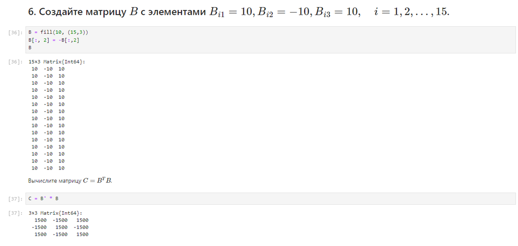

Матрица и произведение

## 7. Создайте матрицу *Z* размерности $6 × 6$, все элементы которой равны нулю, и матрицу *E*, все элементы которой равны $1$. (1)

Используя цикл `while` или `for` и закономерности расположения элементов, создайте определённые матрицы размерности $6 × 6$

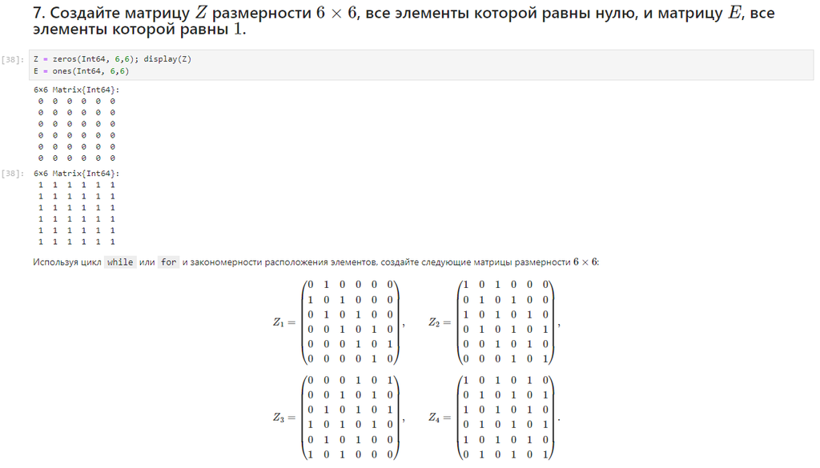

Матрицы Z и закономерности (1)

## 7. Создайте матрицу *Z* размерности $6 × 6$, все элементы которой равны нулю, и матрицу *E*, все элементы которой равны $1$. (2)

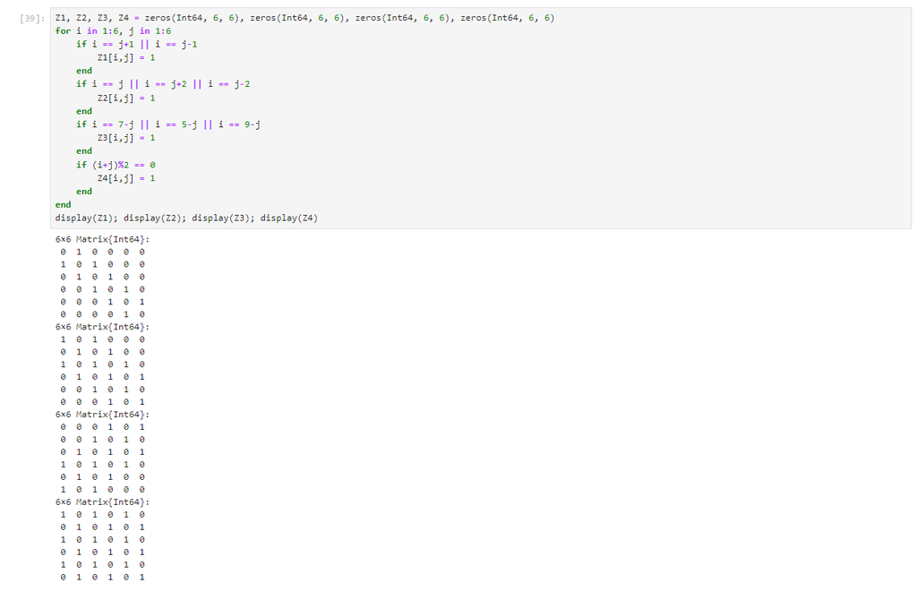

Матрицы Z и закономерности (2)

## 8. В языке R есть функция outer(). (1)

Фактически, это матричное умножение с возможностью изменить применяемую операцию (например, заменить произведение на сложение или возведение в степень).

- Напишите свою функцию, аналогичную функции outer() языка R. Функция должна иметь следующий интерфейс: `outer(x,y,operation)`. Таким образом, функция вида `outer(A,B,*)` должна быть эквивалентна произведению матриц *A* и *B* размерностями *L* × *M* и *M* × *N* соответственно, где элементы результирующей матрицы *C* имеют вид элементов при умножении матрицы.
- Используя написанную вами функцию `outer()`, создайте матрицы определённой структуры.

В каждом случае ваше решение должно быть легко обобщаемым на случай создания матриц большей размерности, но той же структуры.

## 8. В языке R есть функция outer(). (2)

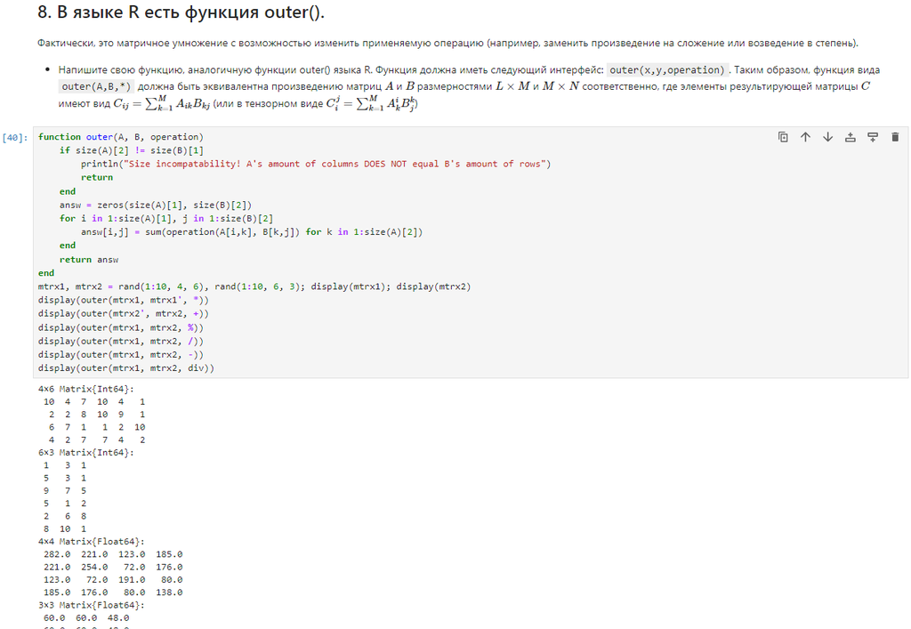

`outer()` (1)

## 8. В языке R есть функция outer(). (3)

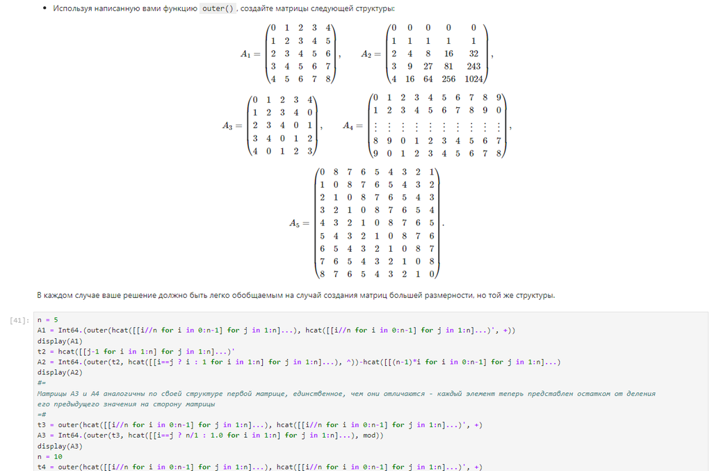

`outer()` (2)

## 8. В языке R есть функция outer(). (4)

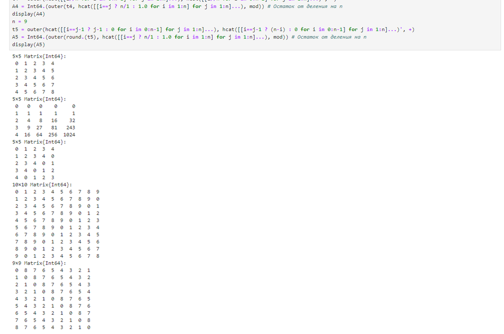

`outer()` (3)

## 9. Решите следующую систему линейных уравнений с 5 неизвестными (1)

рассмотрев соответствующее матричное уравнение *A**x* = *y*. Обратите внимание на особый вид матрицы *A*. Метод, используемый для решения данной системы уравнений, должен быть легко обобщаем на случай большего числа уравнений, где матрица *A* будет иметь такую же структуру.

## 9. Решите следующую систему линейных уравнений с 5 неизвестными (2)

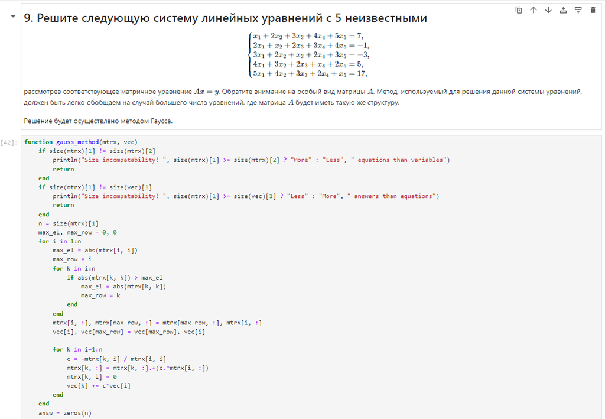

СЛАУ (1)

## 9. Решите следующую систему линейных уравнений с 5 неизвестными (3)

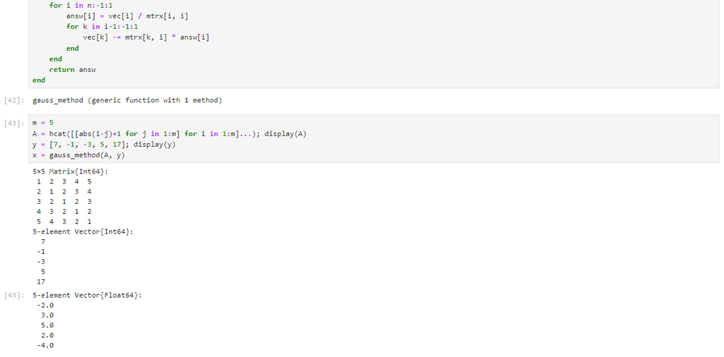

СЛАУ (2)

## 10. Создайте матрицу *M* размерности $6 × 10$, элементами которой являются целые числа, выбранные случайным образом с повторениями из совокупности $1, 2, …, 10$. (1)

- Найдите число элементов в каждой строке матрицы *M*, которые больше числа *N* (например, *N* = 4).
- Определите, в каких строках матрицы *M* число *M*(например, *M* = 7) встречается ровно 2 раза?
- Определите все пары столбцов матрицы *M*, сумма элементов которых больше *K* (например, *K* = 75).

## 10. Создайте матрицу *M* размерности $6 × 10$, элементами которой являются целые числа, выбранные случайным образом с повторениями из совокупности $1, 2, …, 10$. (2)

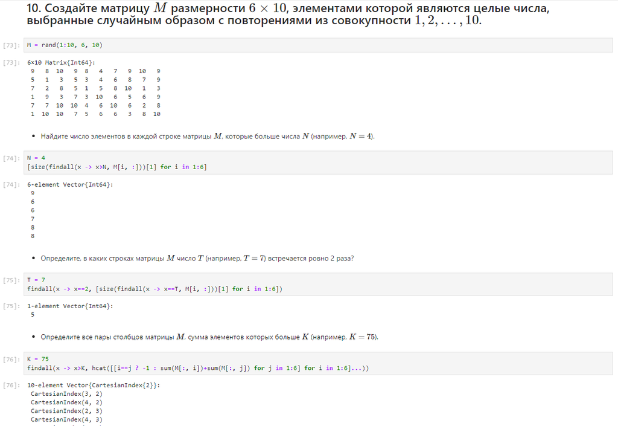

Исследование матрицы M

## 11. Вычислите:

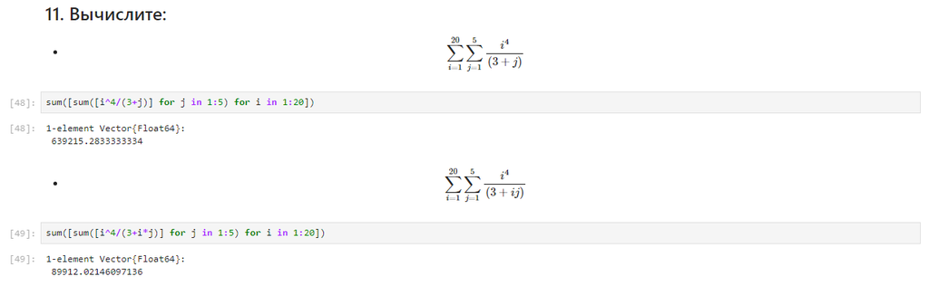

Вычисления

# Выводы по проделанной работе

## Вывод

В результате выполнения работы мы освоили применение циклов функций и сторонних для Julia пакетов для решения задач линейной алгебры и работы с матрицами.

Были записаны скринкасты выполнения и защиты лабораторной работы.